# Compensatory Renal Hypertrophy : miRNA-seq Analysis

Vincent Wong

01 July, 2021

# Setup

First we load all the required `R` packages

```r
library(tidyr)
library(readxl)
library(tidyverse)
library(magrittr)
library(cowplot)
library(edgeR)
library(scales)
library(pander)
library(ggrepel)
library(pheatmap)
library(RColorBrewer)
library(goseq)
library(msigdbr)
library(AnnotationDbi)
library(VennDiagram)
```

```r
panderOptions("table.split.table", Inf)
panderOptions("table.style", "rmarkdown")
panderOptions("big.mark", ",")
```

## Annotations

Sample metadata was also loaded

```r
setwd("C:/Users/cronos/Box Sync/Desktop/Renal Hypertrophy/CRH_smallRNAseq")

samples <- read_csv("samples.csv") %>%
  distinct(sampleName, .keep_all = TRUE) %>%
  dplyr::select(sample = sampleName,time= timepoint, everything()) %>%
  mutate(
    treatment = factor(treatment, levels = c("Sham", "Unx")),
    time = factor(time, levels=c("24hr","48hr","72hr")),
    group = factor(group,
                       levels=c("Sham.24hr", "Sham.48hr", "Sham.72hr",
                                "Unx.24hr", "Unx.48hr", "Unx.72hr")))

groupCols <- samples$group %>%
  levels() %>%
  length() %>%
  brewer.pal("Dark2") %>%
  setNames(levels(samples$group))

timeCols <- samples$time %>%
  levels() %>%
  length() %>%
  brewer.pal("Set2") %>%
  setNames(levels(samples$time))

treatCols <- samples$treatment %>%
  levels() %>%
  length() %>%
  brewer.pal("Set1") %>%
  setNames(levels(samples$treatment)) %>%
  .[-3]
```

## Count Data

Load the microRNA-level counts from QuickMIRSeq output

```r
miR.Counts <- read.csv("C:/Users/cronos/Box Sync/Desktop/Renal Hypertrophy/CRH_smallRNAseq/output_stranded/miR.Counts.csv", row.names=1)

libSizes <- colSums(miR.Counts)
```

## Create DGE List

```r
minCPM <- 1
minSamples <- 6

dgeList <- miR.Counts %>%
    as.data.frame() %>%
  .[rowSums(cpm(.) >= minCPM) >= minSamples,] %>%
  DGEList(
    samples = tibble(sample = colnames(.)) %>%
      left_join(samples),
    genes = rownames(.)) %>%
  calcNormFactors()
```

Initial library sizes were between *4,132,380* and *9,953,415* This dataset retained 552 genes for DGE analysis.

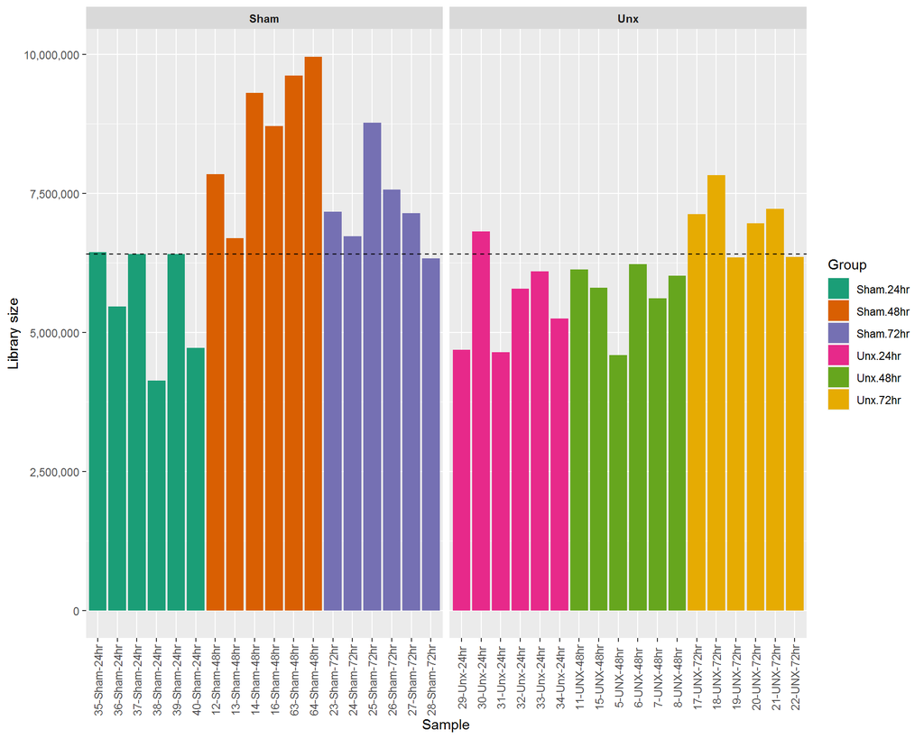

*Library Sizes after removal of undetectable genes and summarising to gene-level counts. Median library size is shown as the dashed line.*

# Analysis

## Initial MDS

MDS: Project a multi-dimensional space preserving the inter-point distances

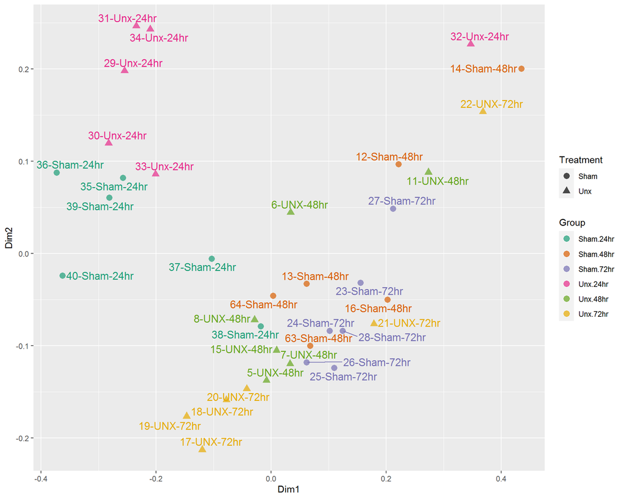

```r
dgeList %>%
    plotMDS(plot = FALSE, labels=colnames(dgeList)) %>%
    .[c("x", "y")] %>%
    as.data.frame() %>%
    set_rownames(colnames(dgeList)) %>%
  rownames_to_column("sample") %>%
    left_join(dgeList$samples) %>%
    ggplot(aes(x, y, colour = group)) +
    geom_point(aes(shape=as.factor(treatment)),alpha = 0.7, size = 3) +
    geom_text_repel(aes(label = label), size=4.4, show.legend = FALSE) +
      scale_colour_manual(values = groupCols)+
    labs(x = "Dim1", y = "Dim2",
         colour = "Group", shape = "Treatment")
```

## Initial PCA

PCA: Project a multi-dimensional space onto the directions of maximum variability

```r
pca <- dgeList %>%
  cpm(log = TRUE) %>%
  t() %>%
  prcomp()
pcaVars <- percent_format(0.1)(summary(pca)$importance["Proportion of Variance",])
```

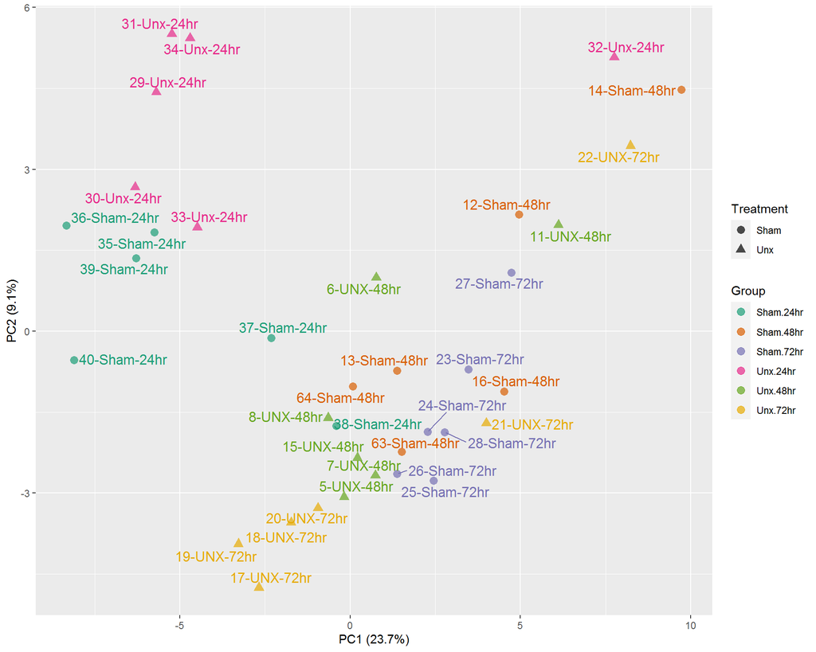

*PCA 1 & 2 of miRNA-level counts.*

```r
pca$x %>%
  as.data.frame() %>%
  rownames_to_column("sample") %>%
  as_tibble() %>%
  dplyr::select(sample, PC1, PC2) %>%
  left_join(dgeList$samples,"sample") %>%
  ggplot(aes(x=PC1, y=PC2, colour = group)) +
  geom_point(aes(shape=as.factor(treatment)),alpha = 0.7, size = 3) +
  geom_text_repel(aes(label = label), size=4.4, show.legend = FALSE) +
  # stat_ellipse(geom = "polygon", alpha = 0.1, show.legend = FALSE, aes(fill=group)) +
  #scale_shape_manual(values=c(15,11,19,17))+ #change shape
  scale_colour_manual(
    values = groupCols) +
  labs(
    x = paste0("PC1 (", pcaVars[["PC1"]], ")"),
    y = paste0("PC2 (", pcaVars[["PC2"]], ")"),
    colour = "Group",
    shape = "Treatment")
```

A Principal Component Analysis (PCA) was performed using logCPM values from each sample.

## Differential Gene Expression

### Creating a design matrix and contrasts

```r
design <- model.matrix(~0+group, data=dgeList$samples)%>%
  set_colnames(str_remove(colnames(.), "group"))
design
```

```
##           Sham.24hr Sham.48hr Sham.72hr Unx.24hr Unx.48hr Unx.72hr
## sRNA10_R1         1         0         0        0        0        0
## sRNA11_R1         1         0         0        0        0        0
## sRNA12_R1         1         0         0        0        0        0
## sRNA13_R1         0         0         0        0        1        0
## sRNA14_R1         0         0         0        0        1        0
## sRNA15_R1         0         0         0        0        1        0
## sRNA16_R1         0         0         0        0        1        0
## sRNA17_R1         0         0         0        0        1        0
## sRNA18_R1         0         0         0        0        1        0
## sRNA19_R1         0         1         0        0        0        0
## sRNA1_R1          0         0         0        1        0        0
## sRNA20_R1         0         1         0        0        0        0
## sRNA21_R1         0         1         0        0        0        0
## sRNA22_R1         0         1         0        0        0        0
## sRNA23_R1         0         1         0        0        0        0
## sRNA24_R1         0         1         0        0        0        0
## sRNA25_R1         0         0         0        0        0        1
## sRNA26_R1         0         0         0        0        0        1
## sRNA27_R1         0         0         0        0        0        1
## sRNA28_R1         0         0         0        0        0        1
## sRNA29_R1         0         0         0        0        0        1
## sRNA2_R1          0         0         0        1        0        0
## sRNA30_R1         0         0         0        0        0        1
## sRNA31_R1         0         0         1        0        0        0
## sRNA32_R1         0         0         1        0        0        0
## sRNA33_R1         0         0         1        0        0        0
## sRNA34_R1         0         0         1        0        0        0
## sRNA35_R1         0         0         1        0        0        0
## sRNA36_R1         0         0         1        0        0        0
## sRNA3_R1          0         0         0        1        0        0
## sRNA4_R1          0         0         0        1        0        0
## sRNA5_R1          0         0         0        1        0        0
## sRNA6_R1          0         0         0        1        0        0
## sRNA7_R1          1         0         0        0        0        0
## sRNA8_R1          1         0         0        0        0        0
## sRNA9_R1          1         0         0        0        0        0
## attr(,"assign")
## [1] 1 1 1 1 1 1
## attr(,"contrasts")
## attr(,"contrasts")$group
## [1] "contr.treatment"
```

```r
contr.matrix <- makeContrasts(
   Sham24vsUnx24 = Unx.24hr-Sham.24hr,
   Sham48vsUnx48 = Unx.48hr-Sham.48hr,
   Sham72vsUnx72 = Unx.72hr-Sham.72hr,
   ShamvsUnx = (Unx.24hr+Unx.72hr+Unx.48hr)-(Sham.24hr+Sham.48hr+Sham.72hr),
   Unx24vsUnx48 = Unx.48hr-Unx.24hr,
   Unx24vsUnx72 = Unx.72hr-Unx.24hr,
   Unx48vsUnx72 = Unx.72hr-Unx.48hr,
   Sham24vsSham48 = Sham.48hr-Sham.24hr,
   Sham24vsSham72 = Sham.72hr-Sham.24hr,
   Sham48vsSham72 = Sham.72hr-Sham.48hr,
   t24vst48 = (Sham.48hr+Unx.48hr)-(Unx.24hr+Sham.24hr),
   t24vst72 = (Unx.72hr+Sham.72hr)-(Unx.24hr+Sham.24hr),
   t48vst72 = (Unx.72hr+Sham.72hr)-(Unx.48hr+Sham.48hr),
   ShamvsUnx24 = (Unx.24hr)-(Sham.24hr+Sham.72hr+Sham.48hr),
   ShamvsUnx48 = (Unx.48hr)-(Sham.24hr+Sham.72hr+Sham.48hr),
   ShamvsUnx72 = (Unx.72hr)-(Sham.24hr+Sham.72hr+Sham.48hr),
   levels = colnames(design))
contr.matrix
```

```
##            Contrasts
## Levels      Sham24vsUnx24 Sham48vsUnx48 Sham72vsUnx72 ShamvsUnx Unx24vsUnx48
##   Sham.24hr            -1             0             0        -1            0
##   Sham.48hr             0            -1             0        -1            0
##   Sham.72hr             0             0            -1        -1            0
##   Unx.24hr              1             0             0         1           -1
##   Unx.48hr              0             1             0         1            1
##   Unx.72hr              0             0             1         1            0
##            Contrasts
## Levels      Unx24vsUnx72 Unx48vsUnx72 Sham24vsSham48 Sham24vsSham72
##   Sham.24hr            0            0             -1             -1
##   Sham.48hr            0            0              1              0
##   Sham.72hr            0            0              0              1
##   Unx.24hr            -1            0              0              0
##   Unx.48hr             0           -1              0              0
##   Unx.72hr             1            1              0              0
##            Contrasts
## Levels      Sham48vsSham72 t24vst48 t24vst72 t48vst72 ShamvsUnx24 ShamvsUnx48
##   Sham.24hr              0       -1       -1        0          -1          -1
##   Sham.48hr             -1        1        0       -1          -1          -1
##   Sham.72hr              1        0        1        1          -1          -1
##   Unx.24hr               0       -1       -1        0           1           0
##   Unx.48hr               0        1        0       -1           0           1
##   Unx.72hr               0        0        1        1           0           0
##            Contrasts
## Levels      ShamvsUnx72
##   Sham.24hr          -1
##   Sham.48hr          -1
##   Sham.72hr          -1
##   Unx.24hr            0
##   Unx.48hr            0
##   Unx.72hr            1
```

### Estimation of sample weights

The approach taken for DGE analysis was to use voom-precision weights in order to allow for modelling using Normally distributed data. Sample-level weights were estimated as part of this process, with all samples normally being considered as belonging to the same treatment group, to allow more conservative estimates.

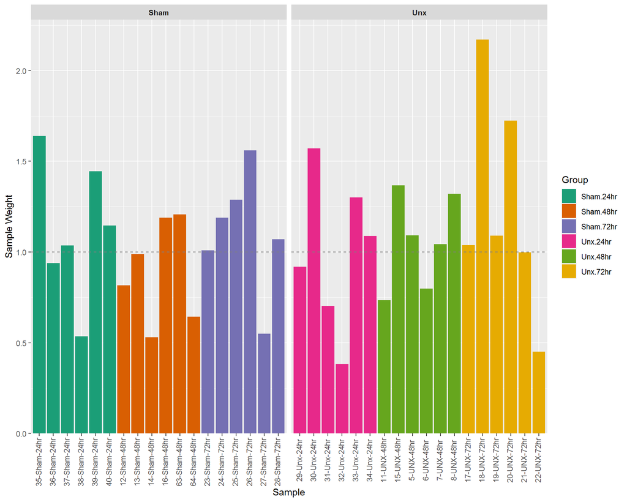

*Sample weights after voom transformation. The idealised equal weighting of $w = 1$ is shown as the dashed line.*

```r
v <- voomWithQualityWeights(dgeList, design, plot=FALSE)
```

Means (x-axis) and variances (y-axis) of each gene are plotted to show the dependence between the two before voom is applied to the data (left panel) and how the trend is removed after voom precision weights are applied to the data (right panel)

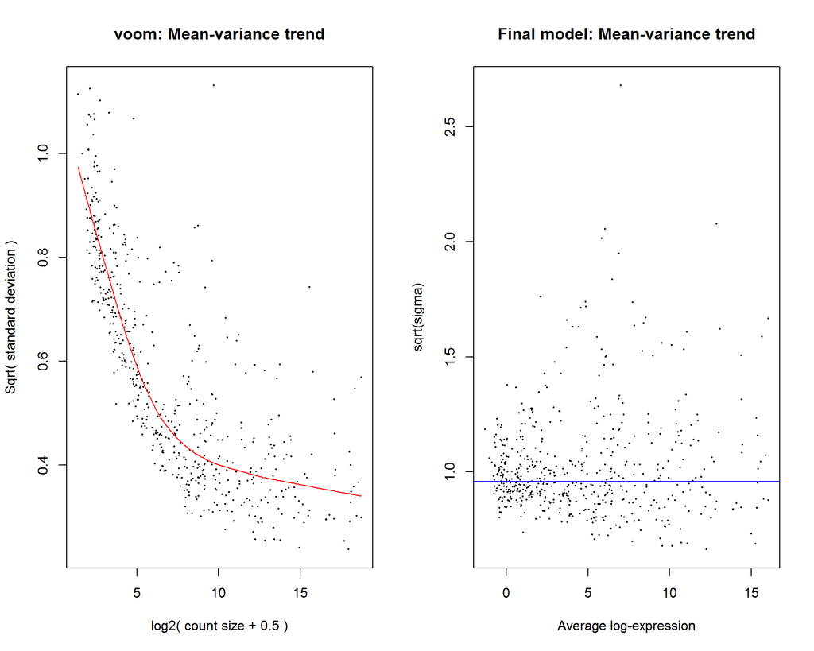

```r
par(mfrow=c(1,2))
v2 <- voom(dgeList, design, plot=TRUE)
v2fit <-lmFit(v2, design)
e2fit <-eBayes(v2fit)
plotSA(e2fit, main="Final model: Mean-variance trend")
```

### Strict Comparison between groups

```r
tau <- log2(1)
```

For the comparison between groups, a null hypothesis was tested using a range of values, instead of the point value zero, i.e.

$$H_0: -\tau < \Delta \mu < \tau \\
Vs. \\
H_A: | \Delta \mu | > \tau$$

The default value used in the function `treat()` is $\tau = \log_2 1.2$ and for this analysis, $\tau = \log_2 1$ was chosen as a suitable value.

```r
alpha <- 0.05

tfit <- lmFit(v,design) %>%
  contrasts.fit(contr.matrix) %>%
  treat(lfc = tau)
```

```r
summary(decideTests(tfit))
```

```
##        Sham24vsUnx24 Sham48vsUnx48 Sham72vsUnx72 ShamvsUnx Unx24vsUnx48
## Down               0             6             0         7           57
## NotSig           552           528           547       514          460
## Up                 0            18             5        31           35
##        Unx24vsUnx72 Unx48vsUnx72 Sham24vsSham48 Sham24vsSham72 Sham48vsSham72
## Down             77            1             72             63              1
## NotSig          414          549            392            425            551
## Up               61            2             88             64              0
##        t24vst48 t24vst72 t48vst72 ShamvsUnx24 ShamvsUnx48 ShamvsUnx72
## Down         89       89        1         450         453         455
## NotSig      354      349      547          86          82          83
## Up          109      114        4          16          17          14
```

```r
topTables <- colnames(contr.matrix) %>%
  sapply(function(x){
  topTreat(tfit, coef = x, n = Inf) %>%
      as_tibble() %>%
      rownames_to_column("No.") %>%
      arrange(P.Value) %>%
      mutate(DE= adj.P.Val < alpha,
             Status = case_when(
      DE ==TRUE & logFC < 0 ~ "Down",
      DE == TRUE & logFC > 0 ~ "Up"),
      Status = ifelse(is.na(Status), "NotSig", Status))}, simplify = FALSE)

# saveRDS(topTables, file="topTables_mirRNA.rds")
#
# #save as CSV
# #have to remove entrezID as some is vector
# for (i in names(topTables_stable)) {
#   filename = paste0(gsub("","",i), ".csv")
#   write.csv(topTables_stable[[i]] %>%
#               dplyr::select(-"entrezid"), filename)}
```

## Intersect with Shashi 48hrs DE

Load Shashi

```r
miRNA_48hr_DiffExpr <- miRNA_48hr_DiffExpr <- read_excel("C:/Users/cronos/Box Sync/Desktop/Renal Hypertrophy/CRH_smallRNAseq/Shashi_smRNA_analysis/Darling_smRNA_analysis/48hr/miRNA_48hr/miRNA-48hr-DiffExpr.xlsx",
    sheet = "miRNA_DiffExpr-Filt", col_types = c("text",
        "numeric", "numeric", "numeric",
        "numeric", "numeric", "numeric",
        "numeric", "numeric", "numeric",
        "numeric", "numeric", "numeric",
        "numeric", "numeric", "numeric",
        "numeric", "numeric", "numeric")) %>%
  as.data.frame() %>% column_to_rownames("miRNA")
```

Extra DE miRs from 48hrs

```r
SM_DE_48 <- miRNA_48hr_DiffExpr %>% dplyr::filter(padj < 0.05) %>% rownames(.)
SM_DE_48
```

```
##  [1] "mmu-miR-126b-3p"  "mmu-miR-26a-2-3p" "mmu-miR-101a-5p"  "mmu-let-7b-5p"
##  [5] "mmu-miR-126a-5p"  "mmu-let-7a-5p"    "mmu-let-7c-5p"    "mmu-let-7g-5p"
##  [9] "mmu-miR-744-5p"   "mmu-miR-98-5p"    "mmu-miR-339-5p"   "mmu-let-7f-5p"
## [13] "mmu-miR-192-5p"   "mmu-miR-200a-5p"  "mmu-miR-423-5p"   "mmu-miR-363-3p"
## [17] "mmu-miR-151-3p"   "mmu-miR-365-2-5p" "mmu-miR-142a-5p"  "mmu-miR-7a-5p"
## [21] "mmu-miR-203b-3p"  "mmu-miR-29a-3p"   "mmu-miR-181c-5p"  "mmu-miR-101b-3p"
## [25] "mmu-miR-1968-5p"
```

Compare with my 48hr DE

```r
VW_DE_48 <- topTables$Sham48vsUnx48 %>% dplyr::filter(DE == TRUE) %>% .$genes
VW_DE_48
```

```
##  [1] "mmu-miR-126a-5p"  "mmu-miR-7a-5p"    "mmu-let-7c-5p"    "mmu-let-7a-5p"
##  [5] "mmu-let-7f-5p"    "mmu-miR-98-5p"    "mmu-let-7b-5p"    "mmu-let-7g-5p"
##  [9] "mmu-miR-21a-5p"   "mmu-miR-423-5p"   "mmu-miR-365-2-5p" "mmu-miR-339-5p"
## [13] "mmu-miR-200a-5p"  "mmu-miR-378b"     "mmu-let-7i-5p"    "mmu-miR-455-5p"
## [17] "mmu-miR-744-5p"   "mmu-miR-5099"     "mmu-miR-29a-3p"   "mmu-miR-363-3p"
## [21] "mmu-miR-142a-5p"  "mmu-miR-181c-5p"  "mmu-miR-331-5p"   "mmu-miR-1195"
```

```r
common_DE <- Reduce(intersect, list(SM_DE_48,VW_DE_48))
common_DE
```

```
##  [1] "mmu-let-7b-5p"    "mmu-miR-126a-5p"  "mmu-let-7a-5p"    "mmu-let-7c-5p"
##  [5] "mmu-let-7g-5p"    "mmu-miR-744-5p"   "mmu-miR-98-5p"    "mmu-miR-339-5p"
##  [9] "mmu-let-7f-5p"    "mmu-miR-200a-5p"  "mmu-miR-423-5p"   "mmu-miR-363-3p"
## [13] "mmu-miR-365-2-5p" "mmu-miR-142a-5p"  "mmu-miR-7a-5p"    "mmu-miR-29a-3p"
## [17] "mmu-miR-181c-5p"
```

VennDiagram

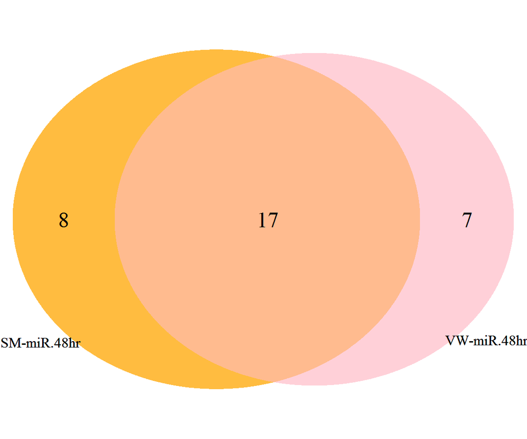

```r
overlap <- calculate.overlap(x = list("Vincent"=VW_DE_48,
                                            "Shashi"=SM_DE_48))

venn.plot<-
  draw.pairwise.venn(
  area1 = length(VW_DE_48),
  area2 = length(SM_DE_48),
  cross.area = 17,
  fill = c("pink", "orange"),
  category = c("VW-miR.48hr", "SM-miR.48hr"),
  lty = "blank", cex = 1.5)

grid.draw(venn.plot)
```

My Boxplot

```r
boxplotVW <- cpm(dgeList, log=TRUE, prior.count = 3)[common_DE,] %>%
  as.data.frame() %>%
  rownames_to_column("gene_id") %>%
    as_tibble() %>%
    gather(key = "sample", value = "CPM", -gene_id) %>%
    mutate(CPM = CPM + 1) %>%
    left_join(dgeList$samples) %>%
  mutate(treatment = fct_relevel(treatment, "Sham","Unx")) %>%
  mutate(group = fct_relevel(group, "Sham.24hr","Sham.48hr","Sham.72hr","Unx.24hr","Unx.48hr","Unx.72hr")) %>%
    ggplot(aes(group, CPM, fill = treatment)) +
  geom_point() +
    # geom_text_repel(aes(label = time)) +
  stat_boxplot(geom='errorbar', linetype=1, width=0.5)+
    geom_boxplot() +
    facet_wrap(
        ~gene_id,
        scales = "free_y") +
  scale_fill_manual(values = treatCols) +
    scale_y_log10()  +
    labs(x = "Treatment Group",
         y = "logCPM + 1") +
    theme(legend.position = "none",axis.text.x = element_text(angle = 90),
          strip.text = element_text(size= 10, face="bold"))
```

Shashi Boxplot

create count matrix from Shashi counts

```r
miRNA_24hr_DiffExpr <- read_excel("C:/Users/cronos/Box Sync/Desktop/Renal Hypertrophy/CRH_smallRNAseq/Shashi_smRNA_analysis/Darling_smRNA_analysis/24hr/miRNA_24hr/miRNA-24hr-DiffExpr.xlsx")

miRNA_48hr_DiffExpr <- read_excel("C:/Users/cronos/Box Sync/Desktop/Renal Hypertrophy/CRH_smallRNAseq/Shashi_smRNA_analysis/Darling_smRNA_analysis/48hr/miRNA_48hr/miRNA-48hr-DiffExpr.xlsx")

miRNA_72hr_DiffExpr <- read_excel("C:/Users/cronos/Box Sync/Desktop/Renal Hypertrophy/CRH_smallRNAseq/Shashi_smRNA_analysis/Darling_smRNA_analysis/72hr/miRNA_72hr/miRNA-72hr-DiffExpr.xlsx")

combined_miRNA_SM <- miRNA_24hr_DiffExpr %>% left_join(by="miRNA", miRNA_48hr_DiffExpr) %>%
  left_join(by="miRNA", miRNA_72hr_DiffExpr) %>% column_to_rownames("miRNA")
```

```r
samplesSM <- read_excel("C:/Users/cronos/Box Sync/Desktop/Renal Hypertrophy/CRH_smallRNAseq/Shashi_smRNA_analysis/Darling_smRNA_analysis/samples.xlsx") %>%
  distinct(sampleName, .keep_all = TRUE) %>%
  dplyr::select(sample = sampleName,time= timepoint, everything()) %>%
  mutate(
    treatment = factor(treatment, levels = c("Sham", "Unx")),
    time = factor(time, levels=c("24hr","48hr","72hr")),
    group = factor(group,
                       levels=c("Sham.24hr", "Sham.48hr", "Sham.72hr",
                                "Unx.24hr", "Unx.48hr", "Unx.72hr")))
groupCols <- samplesSM$group %>%
  levels() %>%
  length() %>%
  brewer.pal("Dark2") %>%
  setNames(levels(samplesSM$group))

timeCols <- samplesSM$time %>%
  levels() %>%
  length() %>%
  brewer.pal("Set2") %>%
  setNames(levels(samplesSM$time))

treatCols <- samplesSM$treatment %>%
  levels() %>%
  length() %>%
  brewer.pal("Set1") %>%
  setNames(levels(samplesSM$treatment)) %>%
  .[-3]
```

```r
dgeListSM <- combined_miRNA_SM %>%
    as.data.frame() %>%
  .[rowSums(cpm(.) >= minCPM) >= minSamples,] %>%
  DGEList(
    samples = tibble(sample = colnames(.)) %>%
      left_join(samplesSM),
    genes = rownames(.)) %>%
  calcNormFactors()
```

```r
boxplotSM <-cpm(dgeListSM, log=TRUE, prior.count = 3)[common_DE,] %>%
  as.data.frame() %>%
  rownames_to_column("gene_id") %>%
    as_tibble() %>%
    gather(key = "sample", value = "CPM", -gene_id) %>%
    mutate(CPM = CPM + 1) %>%
    left_join(dgeListSM$samples) %>%
  mutate(treatment = fct_relevel(treatment, "Sham","Unx")) %>%
  mutate(group = fct_relevel(group, "Sham.24hr","Sham.48hr","Sham.72hr","Unx.24hr","Unx.48hr","Unx.72hr")) %>%
    ggplot(aes(group, CPM, fill = treatment)) +
  geom_point() +
    # geom_text_repel(aes(label = time)) +
  stat_boxplot(geom='errorbar', linetype=1, width=0.5)+
    geom_boxplot() +
    facet_wrap(
        ~gene_id,
        scales = "free_y") +
  scale_fill_manual(values = treatCols) +
    scale_y_log10()  +
    labs(x = "Treatment Group",
         y = "logCPM + 1") +
    theme(legend.position = "none",axis.text.x = element_text(angle = 90),
          strip.text = element_text(size= 10, face="bold"))
```

### Comparison of both DGE miRs in boxplot

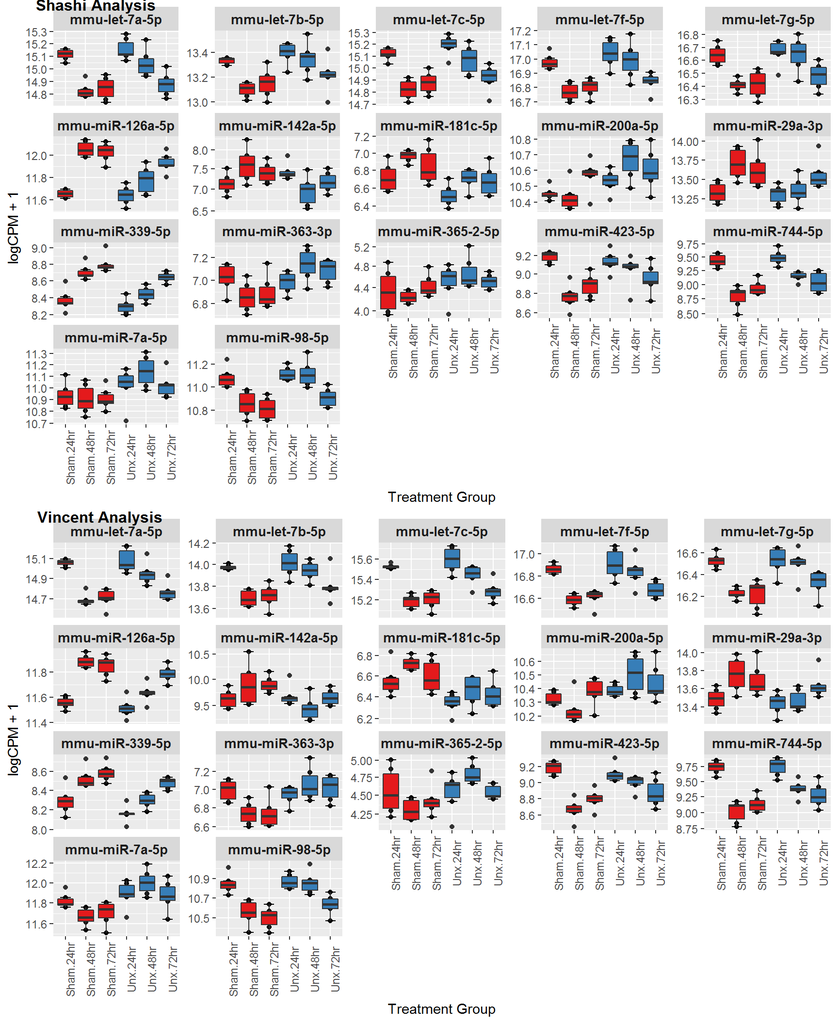

```r
plot_grid(boxplotSM, boxplotVW, labels = c('Shashi Analysis', 'Vincent Analysis'), label_size = 12, ncol=1,vjust=0.9, hjust=-0.3)
```

## Database search for miR-targets

```r
library(multiMiR)
```

```r
multimir_results <- get_multimir(org     = 'mmu',
                                 mirna   = VW_DE_48,
                                 table   = 'validated',
                                 summary = TRUE)
```

```
## Searching mirecords ...
## Searching mirtarbase ...
## Searching tarbase ...
```

```r
head(multimir_results@data)
```

```
##    database mature_mirna_acc mature_mirna_id target_symbol target_entrez
## 1 mirecords     MIMAT0000523   mmu-let-7c-5p           Myc         17869
## 2 mirecords     MIMAT0000521   mmu-let-7a-5p         Hoxa9         15405
## 3 mirecords     MIMAT0000530  mmu-miR-21a-5p         Spry2         24064
## 4 mirecords     MIMAT0000522   mmu-let-7b-5p          Mtpn         14489
## 5 mirecords     MIMAT0000535  mmu-miR-29a-3p           Eln         13717
## 6 mirecords     MIMAT0000535  mmu-miR-29a-3p          Fbn1         14118
##       target_ensembl   experiment support_type pubmed_id      type
## 1 ENSMUSG00000022346 Western blot               17438130 validated
## 2 ENSMUSG00000038227 Western blot               18474618 validated
## 3 ENSMUSG00000022114 Western blot               18508928 validated
## 4 ENSMUSG00000029840 Western blot               15806104 validated
## 5 ENSMUSG00000029675                            18723672 validated
## 6 ENSMUSG00000027204                            18723672 validated
```

```r
a<-multimir_results@data
```

Filter mir interaction based on 48hrs DE genes

```r
topTablesRNA <- readRDS("C:/Users/cronos/Box Sync/Desktop/Renal Hypertrophy/CRH_RNAseq/topTables.rds")

RNA_DE48 <- topTablesRNA$Sham48vsUnx48 %>% dplyr::filter(DE==TRUE) %>%
  dplyr::select(target_ensembl = "gene_id")


b<-a %>% inner_join(RNA_DE48)

b %>% head()
```

```
##    database mature_mirna_acc mature_mirna_id target_symbol target_entrez
## 1 mirecords     MIMAT0000521   mmu-let-7a-5p         Hoxa9         15405
## 2 mirecords     MIMAT0000535  mmu-miR-29a-3p          Fbn1         14118
## 3 mirecords     MIMAT0000535  mmu-miR-29a-3p        Col3a1         12825
## 4 mirecords     MIMAT0000535  mmu-miR-29a-3p        Col1a2         12843
## 5 mirecords     MIMAT0000535  mmu-miR-29a-3p           Yy1         22632
## 6 mirecords     MIMAT0000530  mmu-miR-21a-5p          Btg2         12227
##       target_ensembl   experiment support_type pubmed_id      type
## 1 ENSMUSG00000038227 Western blot               18474618 validated
## 2 ENSMUSG00000027204                            18723672 validated
## 3 ENSMUSG00000026043                            18723672 validated
## 4 ENSMUSG00000029661                            18723672 validated
## 5 ENSMUSG00000021264 Western blot               18977326 validated
## 6 ENSMUSG00000020423                            20432256 validated
```

## Number of targets each miRNA interacts

```r
table(b$mature_mirna_id)
```

```
##
##    mmu-let-7a-5p    mmu-let-7b-5p    mmu-let-7c-5p    mmu-let-7f-5p
##              298              675              555              299
##    mmu-let-7g-5p    mmu-let-7i-5p     mmu-miR-1195  mmu-miR-126a-5p
##              552              491               96               33
##  mmu-miR-142a-5p  mmu-miR-181c-5p  mmu-miR-200a-5p   mmu-miR-21a-5p
##              255              196                1              566
##   mmu-miR-29a-3p   mmu-miR-331-5p   mmu-miR-339-5p   mmu-miR-363-3p
##              272                1               52                9
## mmu-miR-365-2-5p     mmu-miR-378b   mmu-miR-423-5p     mmu-miR-5099
##                4               45                2               15
##   mmu-miR-744-5p    mmu-miR-7a-5p    mmu-miR-98-5p
##                4              484              165
```

## Retrieve interactions between a set of miRNAs and a set of genes

```r
DE_miRNA_up <-topTables$Sham48vsUnx48 %>% dplyr::filter(DE==TRUE & Status=="Up") %>% .$genes
DE_entrez.dn <- topTablesRNA$Sham48vsUnx48 %>% dplyr::filter(DE==TRUE & Status=="Down") %>% .$entrezid %>% unlist()

# search all tables & top 10% predictions
regulation <- get_multimir(org     = "mmu",
                         mirna   = DE_miRNA_up,
                         target  = DE_entrez.dn,
                         table   = "all",
                         summary = TRUE,
                         predicted.cutoff.type = "p",
                         predicted.cutoff      = 10,
                         use.tibble = TRUE)
```

```
## Searching mirecords ...
## Searching mirtarbase ...
## Searching tarbase ...
## Searching diana_microt ...
## Searching elmmo ...
## Searching microcosm ...
## Searching miranda ...
## Searching mirdb ...
## Searching pictar ...
## Searching pita ...
## Searching targetscan ...
## Searching mir2disease ...
## Searching pharmaco_mir ...
## Searching phenomir ...
```

```r
table(regulation@data$type)
```

```
##
## disease.drug    predicted    validated
##           13         3760         2426
```

```r
a<- regulation@data
```

```r
result <- select(regulation, keytype = "type", keys = "validated", columns = columns(regulation))
unique_pairs <-
    result[!duplicated(result[, c("mature_mirna_id", "target_entrez")]), ]

unique_pairs
```

```
## # A tibble: 2,331 x 13
##    database   mature_mirna_acc mature_mirna_id target_symbol target_entrez
##    <chr>      <chr>            <chr>           <chr>         <chr>
##  1 mirecords  MIMAT0000530     mmu-miR-21a-5p  Btg2          12227
##  2 mirecords  MIMAT0000530     mmu-miR-21a-5p  Peli1         67245
##  3 mirecords  MIMAT0000530     mmu-miR-21a-5p  Pdcd4         18569
##  4 mirtarbase MIMAT0000677     mmu-miR-7a-5p   Gla           11605
##  5 mirtarbase MIMAT0000522     mmu-let-7b-5p   Atp6v1b2      11966
##  6 mirtarbase MIMAT0000522     mmu-let-7b-5p   Bach1         12013
##  7 mirtarbase MIMAT0000708     mmu-miR-363-3p  Btg2          12227
##  8 mirtarbase MIMAT0005856     mmu-miR-1195    Car8          12319
##  9 mirtarbase MIMAT0000522     mmu-let-7b-5p   Cbx5          12419
## 10 mirtarbase MIMAT0000122     mmu-let-7i-5p   Col1a2        12843
## # ... with 2,321 more rows, and 8 more variables: target_ensembl <chr>,
## #   experiment <chr>, support_type <chr>, pubmed_id <chr>, type <chr>,
## #   score <chr>, disease_drug <chr>, paper_pubmedID <chr>
```

```r
nested_unique_pairs<- unique_pairs %>% dplyr::select(mature_mirna_id,target_symbol) %>% group_by(mature_mirna_id) %>% nest(target_symbol)

nested_unique_pairs$target_symbols = sapply(nested_unique_pairs$data, function(x) paste(x$target_symbol, collapse = ","))
nested_unique_pairs %>% dplyr::select(mature_mirna_id, target_symbols)
```

```
## # A tibble: 16 x 2
## # Groups:   mature_mirna_id [16]
##    mature_mirna_id  target_symbols
##    <chr>            <chr>
##  1 mmu-miR-21a-5p   Btg2,Peli1,Pdcd4,Sox5,Tgfbr3,Yy1,Map3k1,Rmnd5a,Rc3h1,Dnajc5~
##  2 mmu-miR-7a-5p    Gla,Cry2,Sp1,Zfp26,Clca3a2,Dcaf10,Ndufa9,Ddx3x,Dnajc5,Stk38~
##  3 mmu-let-7b-5p    Atp6v1b2,Bach1,Cbx5,Crk,Epha4,Fut9,Ikbkg,Mtf2,Nrp2,Ppp3r1,R~
##  4 mmu-miR-363-3p   Btg2,Il5ra,Zpbp,Fam136a
##  5 mmu-miR-1195     Car8,Vamp3,Zfp37,Orc4,Commd8,Mga,Fbxl17,Tmx4,Ctps2,Zfp113,R~
##  6 mmu-let-7i-5p    Col1a2,Trim25,Sp1,Lamb1,Stard3nl,Ikbkg,Pex5,Insr,Slc30a4,Kc~
##  7 mmu-miR-5099     Lifr,Abca1,Ppara,Gmfb,Bcl2l2
##  8 mmu-miR-98-5p    Mmp11,Insr,Tgfbr1,Tnpo1,Cbx5,Taok1,Suz12,Ttpal,Crk,Utrn,Pel~
##  9 mmu-miR-744-5p   Cep97,Zfp317,Virma
## 10 mmu-miR-331-5p   Zfp871
## 11 mmu-let-7a-5p    Trim25,Sp1,Pex5,Insr,Slc30a4,Kctd20,Tgfbr1,Slc16a12,Tnpo1,C~
## 12 mmu-let-7c-5p    Trim25,Mmp11,Sp1,Vps50,Lamb1,Stard3nl,Ikbkg,Insr,Slc30a4,Kc~
## 13 mmu-let-7f-5p    Trim25,Sp1,Pex5,Insr,Slc30a4,Kctd20,Tgfbr1,Slc16a12,Tnpo1,C~
## 14 mmu-let-7g-5p    Trim25,Sp1,Cp,Aqp1,Rab11a,Pex5,Insr,Slc30a4,Kctd20,Atp6v1b2~
## 15 mmu-miR-423-5p   Ddx3x,Sinhcaf
## 16 mmu-miR-365-2-5p Igf2bp1,Kdm4c,Fam168b,Mdm4
```